# Final Project

Mingjia Chen, Kuei-Sheng Hou, Raymond Moy, Ruichen Rachel Zhou

2023-03-29

# Background and Significance

## Abstact

Systolic blood pressure is a medical measure that indicates how much pressure blood is exerting against artery walls when the heart beats. The measure is considered as a major risk factor for cardiovascular disease for people over fifty-five years old (American Heart Association, 2023). There may be numerous internal and external factors influencing the volume or level of systolic blood pressure. From our analysis, we have found these significant factors: smoking status, exercise level, height, alcohol use, treatment status, body mass index (BMI), interaction between smoke status and alcohol, and interaction between treatment and BMI.

This case study aims to better understand the relationship between various factors and the blood pressure by speculating and analyzing possible key predicting factors.

The research question is: What Factors Play Significant Role of Influencing Systolic Blood Pressure?

## Variable description

- Gender: gender of the participant (Female = F, Male = M)
- Marital status: (Married = Y, Not Married = N)
- Smoking status: (Smoker = Y, Non-Smoker = N)
- Age: Age of the participants in years
- Weight: in lbs
- Height: in inches
- Body Mass Index (BMI) = (weight/height^2) * 703
- Overweight: Normal = 1, Overweight = 2, Obese = 3
- Race: 1, 2, 3, or 4 (Categorical)
- Exercise level: Low = 1, Medium = 2, High = 3
- Alcohol Use: Low = 1, Medium = 2, High = 3
- Stress level: Low = 1, Medium = 2, High = 3
- Salt (NaCl) Intake Level: Low = 1, Medium = 2, High = 3
- Childbearing Potential: Male = 1, Able Female = 2, Unable Female = 3
- Income Level: Low = 1, Medium = 2, High = 3
- Education Level: Low = 1, Medium = 2, High = 3
- Treatment (for hypertension): Treated = Y, Untreated = N
- Systolic Blood Pressure (SBP): continuous measure

## Split data

use 70% of dataset as training set and 30% as testing set

```r
sample = sample(seq_len(nrow(data)), size = floor(0.7 * nrow(data)), replace = FALSE)
data.train  <- data[sample, ]
data.test   <- data[-sample, ]
```

# Exploratory Data Analysis / Data visualization

## MultiCollinearity

```r
fit <- lm(sbp~ gender + married + smoke + exercise + age + weight + height + overwt + factor(race)
          + alcohol + trt + bmi + stress + salt + chldbear + income + educatn, data = data.train)

fit_simple <- lm(sbp~ 1, data = data.train)
data.numeric = select(data.train, sbp, age, weight, height, bmi)
cor(data.numeric)
```

```
##                sbp          age     weight       height         bmi
## sbp     1.00000000  0.084244062 0.25091583 -0.096521081  0.26909925
## age     0.08424406  1.000000000 0.04713017 -0.009705306  0.05317891
## weight  0.25091583  0.047130166 1.00000000  0.048833235  0.75769945
## height -0.09652108 -0.009705306 0.04883324  1.000000000 -0.59169097
## bmi     0.26909925  0.053178906 0.75769945 -0.591690970  1.00000000
```

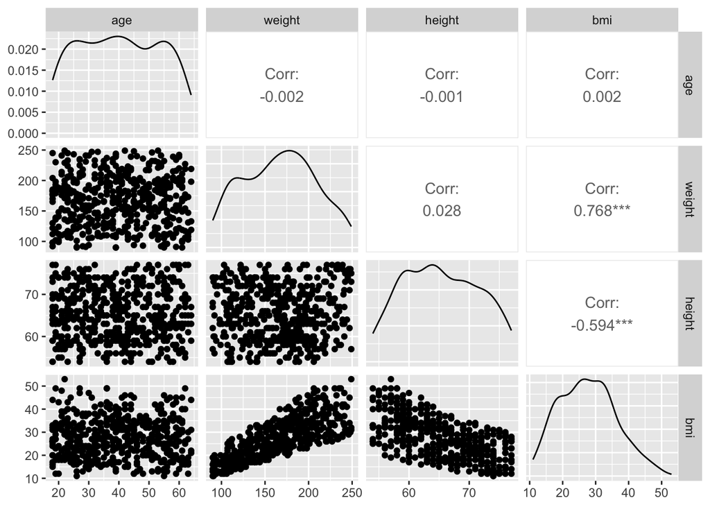

```r
predictors.numeric = select(data, age, weight, height, bmi) #not including the dependent variable
ggpairs(predictors.numeric)
```

From the correlation table, bmi and weight have high correlation and possible multicolinearity.

## Find best model

```r
# step(fit, direction = "backward")$anova
# drop1(lm(sbp ~ smoke + exercise + age + height + alcohol + trt + bmi, data = data.train),
#       test = "Chisq")
# anova(lm(sbp ~ smoke + exercise + height + alcohol + trt + bmi, data = data.train),
#       lm(sbp ~ smoke + exercise + age + height + alcohol + trt + bmi, data = data.train),
#       test = "Chisq")
best_fit_backward = lm(sbp ~ smoke + exercise + height + alcohol + trt + bmi, data = data.train)
```

After testing, best model for backward direction is sbp ~ smoke + exercise + height + alcohol + trt + bmi AIC = 2288.4

```r
# step(fit_simple, scope=list(upper = fit, lower = fit_simple),direction = "forward")$anova
# drop1(lm(sbp ~ bmi + trt + smoke + exercise + alcohol + height + age, data = data.train),
#       test = "Chisq")
# anova(lm(sbp ~ bmi + trt + smoke + exercise + alcohol + height, data = data.train),
#       lm(sbp ~ bmi + trt + smoke + exercise + alcohol + height + age, data = data.train),
#       test = "Chisq")
best_fit_forward = lm(formula = sbp ~ bmi + exercise + smoke + trt + height + alcohol,
                      data = data.train)
```

After testing, best model for forward direction is sbp ~ bmi + exercise + smoke + trt + height + alcohol, which is the same model as backward direction. AIC = 2288.4

## Check interaction in both direction

```r
fit_inter <- lm(sbp ~ (smoke*exercise*height*alcohol*trt*bmi), data = data.train)
# step(fit_inter, direction = "backward")$anova
# anova(lm(sbp ~ smoke + exercise + height + alcohol + trt + bmi + smoke:alcohol + trt:bmi, data = data.train),
#       lm(sbp ~ smoke + exercise + height + alcohol + trt + bmi + smoke:alcohol + smoke:trt + trt:bmi,
#          data = data.train), test = "Chisq")
# drop1(lm(sbp ~ smoke + exercise + height + alcohol + trt + bmi + smoke:alcohol + trt:bmi,
#          data = data.train), test = "Chisq")

best_fit_inter_backward = lm(sbp ~ smoke + exercise + height + alcohol + trt +
                               bmi + smoke:alcohol + trt:bmi, data = data.train)
```

AIC = 2277.34  
Best model with interaction term is using backward selection: sbp ~ smoke + exercise + height + alcohol + trt + bmi + smoke:alcohol + trt:bmi

```r
# step(fit_simple, scope=list(upper = fit_inter, lower = fit_simple),direction = "forward")$anova
best_fit_inter_forward = lm(sbp ~ bmi + trt + smoke + exercise + alcohol + height + bmi:trt +
                              smoke:alcohol, data = data.train)
```

AIC=2277.34  
Best model with interaction term is using forward selection: sbp ~ bmi + trt + smoke + exercise + alcohol + height + bmi:trt + smoke:alcohol which is the same model as backward selection

## Models with interaction and without

```r
anova(best_fit_backward, best_fit_inter_backward, test = "Chisq")
```

|  | Res.Df | RSS | Df | Sum of Sq | Pr(>Chi) |
| --- | --- | --- | --- | --- | --- |
| 1 | 341 | 229777.7 | NA | NA | NA |
| 2 | 338 | 218830.9 | 3 | 10946.85 | 0.0007381425 |

```r
best_model = best_fit_inter_backward
```

from the anova test, the complex model is better best_model = sbp ~ smoke + exercise + height + alcohol + trt + bmi + smoke:alcohol + trt:bmi

# Checking LINE assumptions

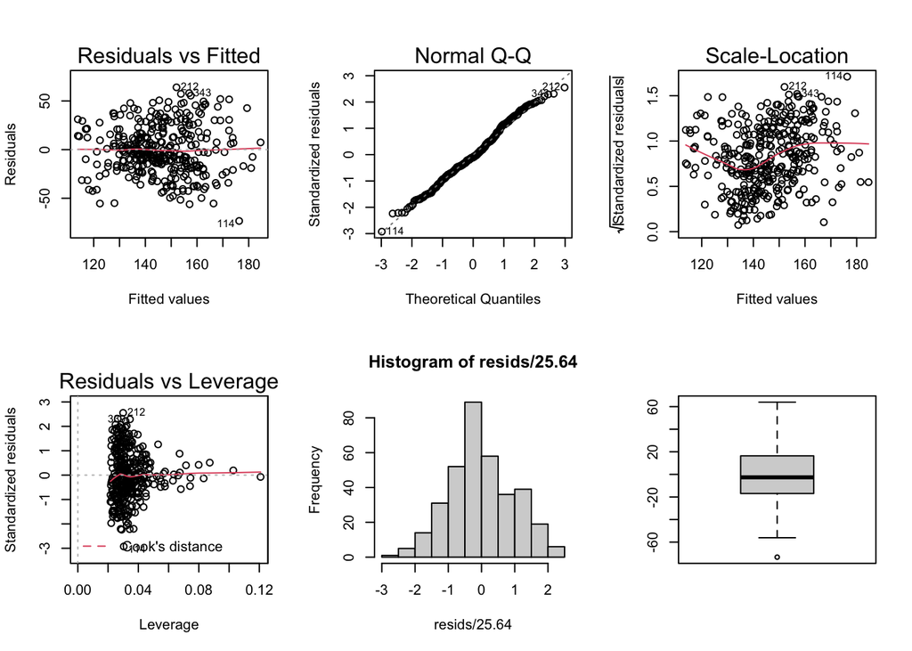

```
##
##  Shapiro-Wilk normality test
##
## data:  resids
## W = 0.99248, p-value = 0.07527
```

```
##
##  studentized Breusch-Pagan test
##
## data:  best_model
## BP = 46.032, df = 11, p-value = 3.192e-06
```

- resid vs fitted plot: seems okay, very clustered around 0.
- QQplot looking very good. some minor outliers, around the ends
- 2 outlying leverage points
- histogram hist of semi-studentised resids looks vaguely normal, slightly skewed to the left
- boxplot: one very apparent outlier
- Shapiro–Wilk test: p-value is > 0.05 we fail to reject the null hypothesis, would indicate that the resids are normal
- Breusch-Pagan Test: reject the null hypothesis that the resid variances are equal we have evidence that the residual variances are NOT equal!

## MultiCollinearity

Correlation Matrix:

```
##                sbp      height        bmi
## sbp     1.00000000 -0.09652108  0.2690993
## height -0.09652108  1.00000000 -0.5916910
## bmi     0.26909925 -0.59169097  1.0000000
```

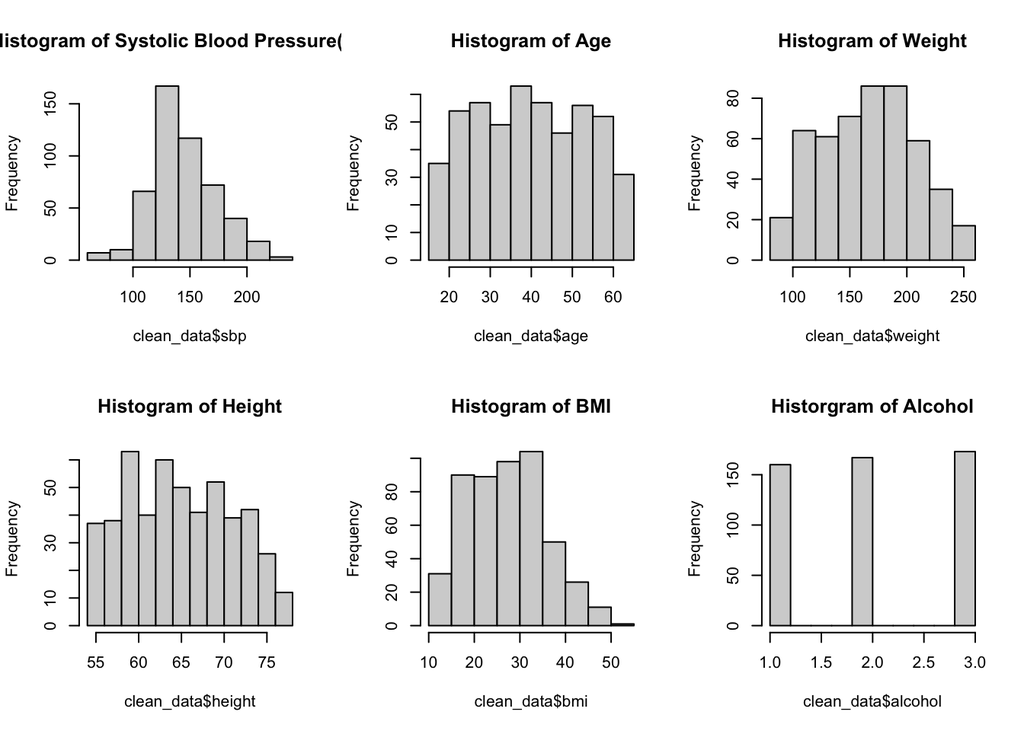

Graph for SBP-> slightly skewed, closest to normal distribution. No particular observation can be made for the remaining graphs.

By calculating the summary and sd from cleaned data, we obtain two summary tables:

| Variables | Descriptions | Min | Q1 | Median | Mean | Q3 | Max | SD |
| --- | --- | --- | --- | --- | --- | --- | --- | --- |
| sbp | Systolic Blood Pressure(SBP) | 67 | 130 | 140.5 | 145 | 162.2 | 224 | 28 |
| age | years | 18 | 28 | 40 | 40 | 52 | 64 | 13.3 |
| weight | lbs | 90 | 133 | 168 | 166.6 | 198 | 249 | 40.9 |
| height | inches | 54 | 60 | 65 | 65.33 | 70 | 77 | 6.2 |
| bmi | Body Mass Index(BMI) | 11 | 21 | 27 | 27.66 | 33 | 53 | 8.6 |

| Variables | Categories | n |
| --- | --- | --- |
| Gender | Female | 264 |
|  | Male | 236 |
| Smoking | yes | 266 |
|  | no | 234 |
| Exercise | low | 195 |
|  | medium | 136 |
|  | high | 169 |
| Alcohol | low | 160 |
|  | medium | 167 |
|  | high | 173 |
| Treatment | yes | 101 |
|  | no | 399 |

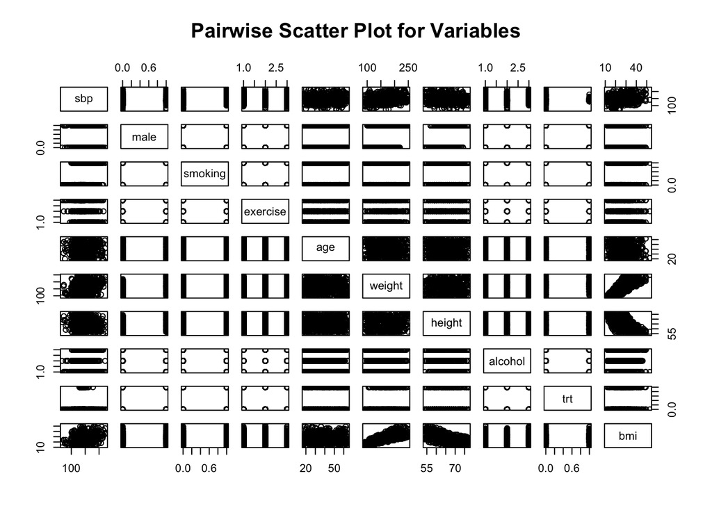

```r
fit1 <- lm(sbp ~ . , data = clean_data)
fit2 <- lm(sbp ~ smoking + exercise + alcohol + trt + bmi, data = clean_data)
full <- lm(sbp ~ . , data = data)
fit.null <- lm(sbp ~ 1, data = data)
model <- step(fit.null,direction = "forward", scope = list("lower" = fit.null, "upper" = full), trace = 0)

# multiple regression model
AICs = c(AIC(fit1),AIC(fit2),AIC(model))
AICs
```

```
## [1] 4667.657 4667.885 4660.987
```

fit1 and fit2 have similar AIC values

# Model Validation / Diagnostics

```r
##### Obtain validation sets
set.seed(12345)
n = nrow(clean_data)
cv.samp <- sample(1:n, round(0.5*n),replace = FALSE)
cv.in <- clean_data[cv.samp,]
cv.out <- clean_data[-cv.samp,]

##### fit model for training set
fit.cv.in <- lm(sbp ~ smoking+exercise+alcohol+trt+bmi, data=cv.in)
anova(fit.cv.in)
```

|  | Df | Sum Sq | Mean Sq | F value | Pr(>F) |
| --- | --- | --- | --- | --- | --- |
| smoking | 1 | 7738.756 | 7738.7564 | 11.401730 | 8.537272e-04 |
| exercise | 1 | 5791.789 | 5791.7890 | 8.533207 | 3.814101e-03 |
| alcohol | 1 | 1365.020 | 1365.0204 | 2.011123 | 1.574255e-01 |
| trt | 1 | 6341.503 | 6341.5031 | 9.343117 | 2.487228e-03 |
| bmi | 1 | 15728.516 | 15728.5164 | 23.173270 | 2.597628e-06 |
| Residuals | 244 | 165611.411 | 678.7353 | NA | NA |

```r
##### Obtain Predicted  values and prediction errors for validation sample
##### Regression is based on same predictors
##### Compute MSPR
pred.cv.out <- predict(fit.cv.in, cv.out[,c(3,4,8,9,10)])
delta.cv.out <- clean_data[-cv.samp,]-pred.cv.out
n.star = dim(cv.out)[1]
MSPR <- sum(delta.cv.out)^2/n.star
MSPR
```

```
## [1] 255260891
```

```r
#Fit Model on Validation Sample and Compare regression coefficients with model for Training Sample
fit.cv.out <- lm(sbp ~ smoking+exercise+alcohol+trt+bmi, data=cv.out)
anova(fit.cv.out)
```

|  | Df | Sum Sq | Mean Sq | F value | Pr(>F) |
| --- | --- | --- | --- | --- | --- |
| smoking | 1 | 6940.508 | 6940.5076 | 10.899999 | 1.105599e-03 |
| exercise | 1 | 3930.391 | 3930.3914 | 6.172641 | 1.364576e-02 |
| alcohol | 1 | 7844.947 | 7844.9475 | 12.320413 | 5.334495e-04 |
| trt | 1 | 2969.606 | 2969.6061 | 4.663737 | 3.178076e-02 |
| bmi | 1 | 11445.543 | 11445.5432 | 17.975113 | 3.177556e-05 |
| Residuals | 244 | 155365.504 | 636.7439 | NA | NA |

|  | $\hat{\beta_0}$ | $\hat{\beta_1}$ | $\hat{\beta_2}$ | $\hat{\beta_3}$ | $\hat{\beta_4}$ | $\hat{\beta_5}$ | $\R^2_{adj}$ |
| --- | --- | --- | --- | --- | --- | --- | --- |
| Training | 117.05 (8.45) | 10.96 (3.38) | -5.85 (1.94) | 4.76 (2.03) | -15.28 (4.17) | 0.99 (0.21) | 0.1657 |
| Validation | 114.32 (7.67) | 10.66 (3.21) | -4.47 (1.89) | 6.84 (2.00) | -9.57 (4.03) | 0.77 (0.18) | 0.1589 |

Since the regression results for training and validation dataset are similar, we can conclude that the model is valid and we can make reference on the model

## Outlying & Influential Points

```r
influences = influence.measures(best_model)
# Y outlying points
best_model = lm(sbp ~ bmi + trt + smoke + exercise + alcohol + height + bmi:trt
                + smoke:alcohol, data = data)
# studentized deleted residuals
t = rstudent(best_model)
#standardized residuals
r = rstandard(best_model)
rt.table = cbind(r,t)

alpha = 0.05
n = dim(data)[1]
p.prime = length(coef(best_model))

t.crit = qt(1-alpha/(2*n), n - p.prime - 1)
t.crit
```

```
## [1] 3.922859
```

```r
which(abs(t) > t.crit)
```

```
## named integer(0)
```

We got named integer(0) for result, meaning no outlier observation of Y according to studentized deleted residual.

```r
# X outlying points
hii = hatvalues(best_model)
which(hii > 2*p.prime/n)
which(hii > 0.05)
```

[output not shown]

```r
#Influential observations
DFFITTS = dffits(best_model)
which(DFFITTS >1)
```

```
## named integer(0)
```

```r
#Cook's Distance
D = cooks.distance(best_model)
which(D>qf(0.2,p.prime,n-p.prime))
```

```
## named integer(0)
```

```r
DFBETAS = dfbetas(best_model)
which(DFBETAS > 1)
```

```
## integer(0)
```

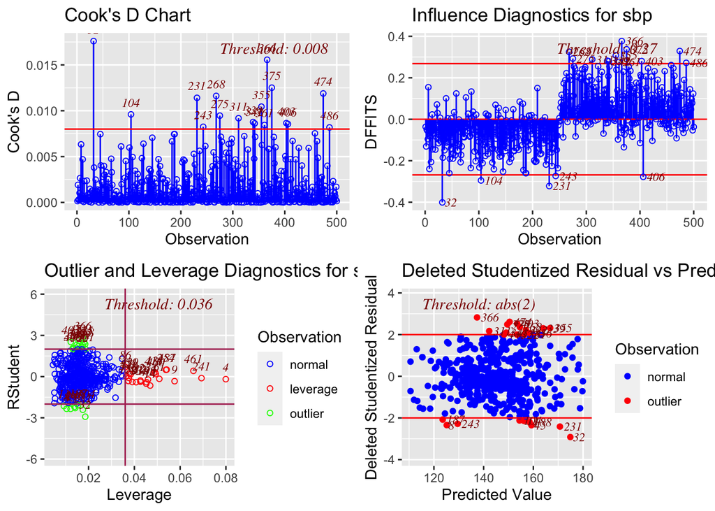

According to BFFITS, D and DFBETAS, we do not have influential observations in the data.  
Even though there are outliers of X observations, we decide to keep them as they are. Outliers are not too rare in real life scenarios. As long as there are no influential observations in the model, we will stick to the original X dataset. This may also help us avoid the problem of overfitting.

# Reference

Understanding blood pressure readings. www.heart.org. (2023, February 2). Retrieved April 2, 2023, from https://www.heart.org/en/health-topics/high-blood-pressure/understanding-blood-pressure-readings